# R-Workshop im ZEIF-Kolloquium

Author

Pawel R. Kulawiak

[figure not shown]

**Infos**

Da die ersten Termine im ZEIF-Kolloquium noch frei waren, möchte ich beim ersten Termin einen R-Workshop anbieten.

Der Workshop richtet sich an **absolute R-Anfänger:innen**. **R-Profis** sind aber auch herzlich willkommen, um die **R-Anfänger:innen** zu unterstützen (**Peer-Tutoring und sozialer Austausch**).

- Oktober 19. (2023)
- 10:15 Uhr
- Haus 31, Raum 1.18

**Bitte R und R-Studio installieren**

Bitte Installationsanleitung folgen (Step 1 und Step 2):

- 1: Install R
- 2: Install RStudio

https://posit.co/download/rstudio-desktop/

| Datum | Thema |
| --- | --- |
| Okt 19. | Grundlagen |
| Nov 9. | HTML-Berichte mit Quarto: https://quarto.org/ |

# Grundlagen (19.10.23)

**Lernergebnisse**

- Was ist R?
- Was ist R-Studio?
- Daten- und Datenstrukturen
- Basale Analysen
  - Mittelwerte und Co.
  - Korrelation und Regression
- Visualisierungen
- Zusatzpakete (installieren und laden)
- Datenimport und Datenexport

## Was kann man mit R und R-Studio machen?

Beispiele:

https://pawelkulawiak.github.io/epi/

https://kulawiak.shinyapps.io/episurvey/

https://pawelkulawiak.github.io/textmininginclusion/

## Daten- und Datenstrukturen

### Vektoren

```r
ID <- c(1, 2, 3, 4, 5)
AGE <-  c(3, 3.5, NA, 6, 7)
IQ <- c(5, 4, 5, 3, 4)
SEX <- c("m", "f", "f", "m", "m")
```

### Datensatz

```r
DATA <- data.frame(ID, AGE, IQ, SEX)
```

```r
DATA
```

```
  ID AGE IQ SEX
1  1 3.0  5   m
2  2 3.5  4   f
3  3  NA  5   f
4  4 6.0  3   m
5  5 7.0  4   m
```

**👷‍♂️ Übung**

Befrage die Workshopteilnehmer:innen:

- Vorname
- Lieblingshobby
- Körpergröße (in cm)
- Schuhgröße (in cm)

Erstelle mit diesen Informationen einen Datensatz für alle Workshopteilnehmer:innen.

## Basale Analysen

```r
DATA$AGE
```

```
[1] 3.0 3.5  NA 6.0 7.0
```

```r
mean(DATA$AGE)
```

```
[1] NA
```

```r
?mean()
```

```
starting httpd help server ... done
```

```r
mean(DATA$AGE, na.rm = TRUE)
```

```
[1] 4.875
```

```r
mean(DATA$AGE, na.rm = T)
```

```
[1] 4.875
```

### Pipe

```r
# Der Pipe-Operator (strg + M)
DATA$AGE %>% mean(na.rm = T)
```

```r
# Der Pipe-Operator aus dem Zusatzpaket magrittr (tidyverse)
DATA$AGE %>%
  mean(na.rm = T)
```

```
[1] 4.875
```

```r
# Der Base-Pipe-Operator
DATA$AGE |>
  mean(na.rm = T)
```

```
[1] 4.875
```

https://magrittr.tidyverse.org/reference/pipe.html

https://www.tidyverse.org/blog/2023/04/base-vs-magrittr-pipe/

https://r4ds.had.co.nz/pipes.html

https://www.tidyverse.org/

**Übung**

1. Bestimme Median und Standardabweichung für die Schuhgröße (mit Pipe / ohne Pipe)
2. Mach eine Häufigkeitstabelle (absolute Häufigkeit) des Lieblingshobbys (mit Pipe / ohne Pipe)

### Korrelation und Regression

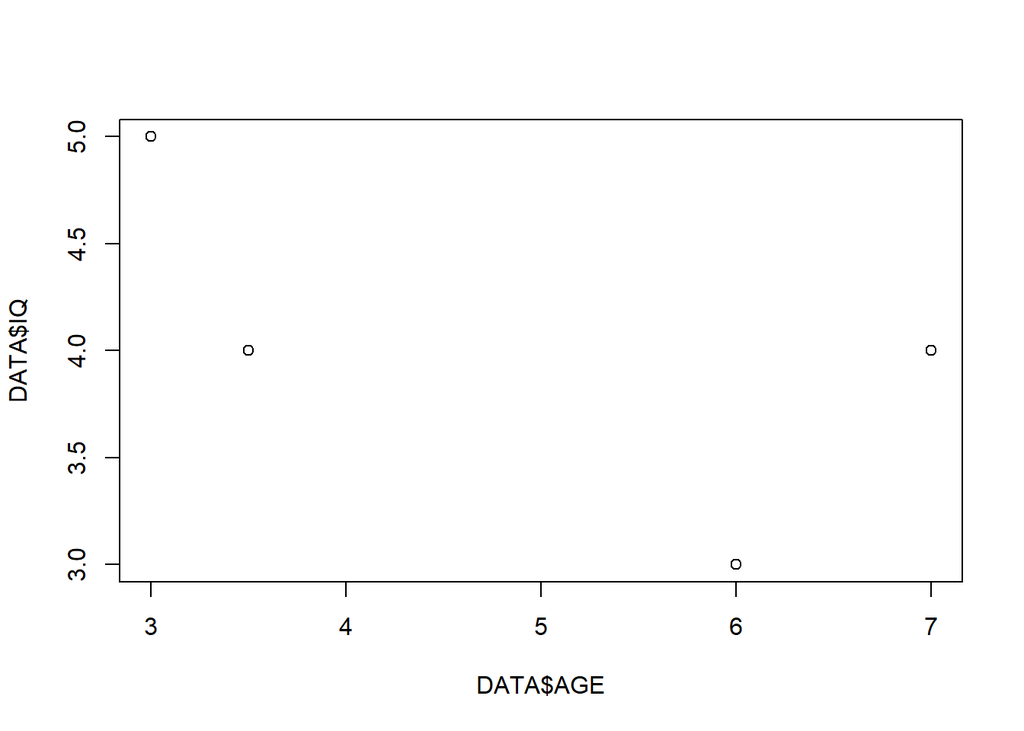

```r
plot(DATA$AGE, DATA$IQ)
```

```r
?cor
```

```r
cor(DATA$AGE, DATA$IQ, use = "complete.obs")
```

```
[1] -0.6342197
```

```r
lm(IQ ~ AGE, data = DATA)
```

```
Call:
lm(formula = IQ ~ AGE, data = DATA)

Coefficients:
(Intercept)          AGE
     5.3073      -0.2682
```

```r
lm(IQ ~ AGE, data = DATA) |>
  summary()
```

```
Call:
lm(formula = IQ ~ AGE, data = DATA)

Residuals:
      1       2       4       5
 0.4972 -0.3687 -0.6983  0.5698

Coefficients:
            Estimate Std. Error t value Pr(>|t|)
(Intercept)   5.3073     1.1913   4.455   0.0469 *
AGE          -0.2682     0.2312  -1.160   0.3658
---
Signif. codes:  0 '***' 0.001 '**' 0.01 '*' 0.05 '.' 0.1 ' ' 1

Residual standard error: 0.7732 on 2 degrees of freedom
  (1 observation deleted due to missingness)
Multiple R-squared:  0.4022,    Adjusted R-squared:  0.1034
F-statistic: 1.346 on 1 and 2 DF,  p-value: 0.3658
```

```r
library(sjPlot)
```

```r
lm(IQ ~ AGE, data = DATA) |>
  tab_model()
```

|  | IQ |  |  |
| --- | --- | --- | --- |
| Predictors | Estimates | CI | p |
| (Intercept) | 5.31 | 0.18 – 10.43 | **0.047** |
| AGE | -0.27 | -1.26 – 0.73 | 0.366 |
| Observations | 4 |  |  |
| R<sup>2</sup> / R<sup>2</sup> adjusted | 0.402 / 0.103 |  |  |

https://strengejacke.github.io/sjPlot/

https://strengejacke.github.io/sjPlot/articles/tab_model_estimates.html

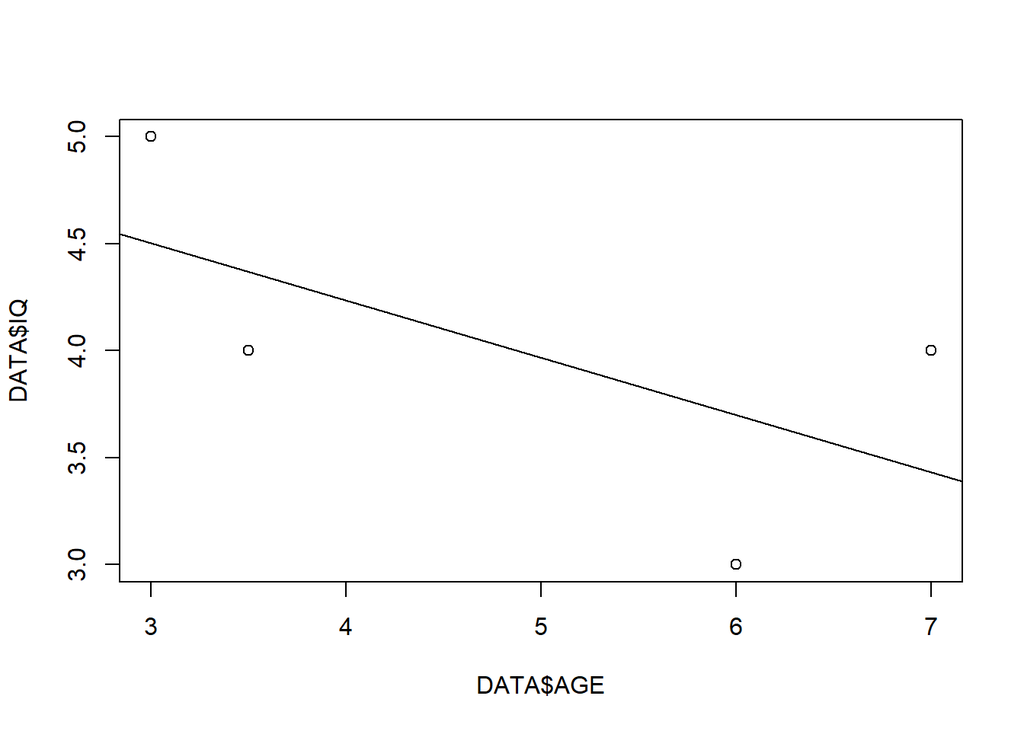

```r
plot(DATA$AGE, DATA$IQ)
lm(IQ ~ AGE, data = DATA) |>
  abline()
```

**👷‍♂️ Übung**

Kann man die Schuhgröße anhand der Körpergröße vorhersagen?

1. Berechne die Korrelation.
2. Mach eine Regressionstabelle als HTML-Output
3. Erstelle ein Streudiagramm mit Regressionsgerade (mach die Linie grün 🍀)
4. Erstelle einen Titel für das Streudiagramm
5. Verändere die Beschriftung der X- und Y-Achsen

## Datenimport und -export

### Export

```r
write.csv2(DATA, "DATA.csv") # use write.csv() with US-Computers
```

### Import

```r
NEW_DATA <- read.csv2("DATA.csv") # use read.csv() with US-Computers
```

**👷‍♂️ Übung**

Exportieren und importieren Sie den Datensatz mit den Schuhgrößen.

### Andere Formate

- https://cran.r-project.org/web/packages/foreign/foreign.pdf z.B. `read.spss()`
- https://readr.tidyverse.org/
- https://readxl.tidyverse.org/
- https://googlesheets4.tidyverse.org/

### Literaturempfehlungen (Hausaufgabe: Üben, Üben, Üben)

- https://r4ds.hadley.nz/
- https://r4ds.had.co.nz/pipes.html
- https://r4ds.hadley.nz/base-r
- https://r4ds.hadley.nz/import
- https://r4ds.hadley.nz/spreadsheets

# HTML-Berichte mit R und Quarto (09.11.23)

## Infos über Quarto

- https://quarto.org/docs/get-started/hello/rstudio.html
- https://www.youtube.com/watch?v=_f3latmOhew

**Lernergebnisse**

- Markdown (markup language)
- HTML-Berichte erstellen
- **Beispiel**: https://pawelkulawiak.github.io/epi/

## Struktur eines Quarto-Dokuments

**Dateiendung: *.qmd**

```
---
title: "Forschungsbericht"
author: "Pawel R. Kulawiak"
format: html
embed-resources: true
toc: true
---

![](https://raw.githubusercontent.com/PawelKulawiak/site/main/images/potsdam.png){width="20%"}

Universität Potsdam

[kulawiak@uni-potsdam.de](mailto:kulawiak@uni-potsdam.de)

<https://www.uni-potsdam.de/de/inklusion/forschungsmethodenunddiagnostik/kulawiak>

# Abstract

bla, bla

# Einleitung

kursives *bla bla*

Das sind die Markdown-Regeln zum Schreiben:

<https://www.markdownguide.org/cheat-sheet/>

## Fragestellung

fettes **bla bla**

## Hypothesen

fett-kursives ***bla bla***

# Ergenisse
```

## Markdown

**Das sind die Markdown-Regeln zum Schreiben**

- https://www.markdownguide.org/cheat-sheet/

## Analysen für den Forschungsbericht

### Vorbereitung der Daten

```r
library(tidyverse) # R-Zusatz tidyverse

iris <-
  iris |>
  mutate(Species = case_when(Species == "setosa" ~ "language",
                         Species == "versicolor" ~ "emotional",
                         Species == "virginica" ~ "physical"))
names(iris) <- c("MATH", "GERMAN", "ENGLISH", "SPORT", "SEN")
```

### Welche Gruppe (SEN) ist am sportlichsten?

```r
iris |>
  group_by(SEN) |>
  summarise("M" = mean(SPORT),
            "SD" = sd(SPORT),
            "Md" = median(SPORT))
```

```
# A tibble: 3 × 4
  SEN           M    SD    Md
  <chr>     <dbl> <dbl> <dbl>
1 emotional 1.33  0.198   1.3
2 language  0.246 0.105   0.2
3 physical  2.03  0.275   2
```

Diese Tabelle sieht nicht schön aus (keine HTML-Tabelle). Wir erstellen nun eine HTML-Tabelle mit dem Befehl `flextable()` aus dem R-Zusatzpaket `flextable`:

- https://davidgohel.github.io/flextable/
- https://ardata-fr.github.io/flextable-book/

**R-Zusatzpaket `flextable` installieren und laden**

`library(flextable)`

```r
library(flextable)

iris |>
  group_by(SEN) |>
  summarise(
    "n" = n(),
    "M" = mean(SPORT),
    "SD" = sd(SPORT),
    "Md" = median(SPORT)) |>
  flextable()
```

Sportleistung nach Gruppe (SEN)

| SEN | n | M | SD | Md |
| --- | --- | --- | --- | --- |
| emotional | 50 | 1.326 | 0.1977527 | 1.3 |
| language | 50 | 0.246 | 0.1053856 | 0.2 |
| physical | 50 | 2.026 | 0.2746501 | 2.0 |

#### Visualisierung

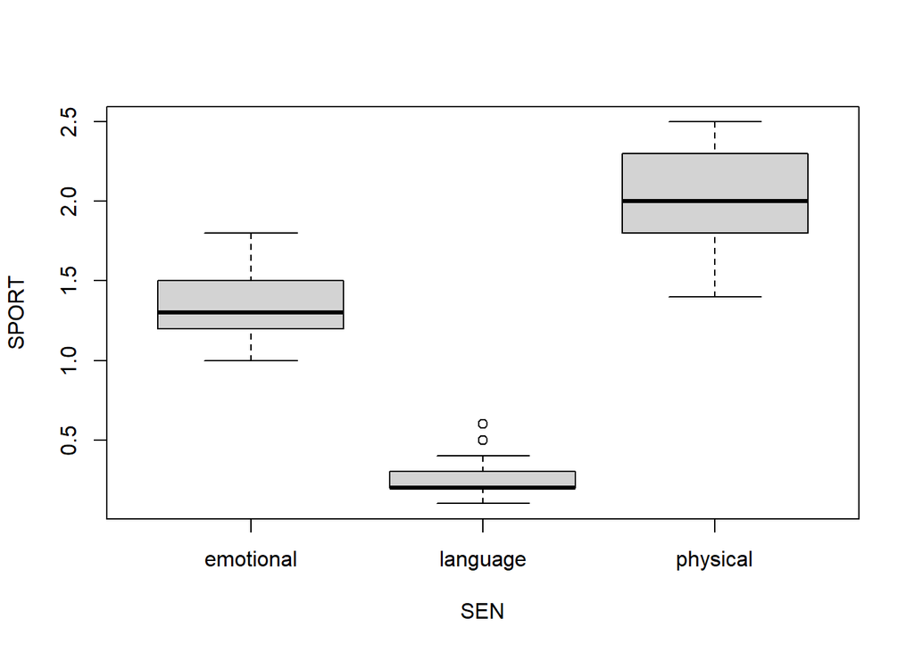

```r
boxplot(SPORT ~ SEN, data = iris)
```

### Welche Gruppe (SEN) spricht am besten Englisch?

**👷‍♂️ Übung**

Welche Gruppe (SEN) spricht am besten Englisch?

1. Erstelle eine HTML-Ergebnistabelle mit folgenden Parametern:
   - Gruppengröße
   - Mittelwert
   - Median
   - Standardabweichung
   - Minimum
   - Maximum
2. Visualisiere den Sachverhalt mit Boxplots und wähle unterschiedliche Farben 🎨 für die Boxplots.

### Vorhersage der Englisch-Leistung anhand der Sport-Leistung

#### Visualisierung

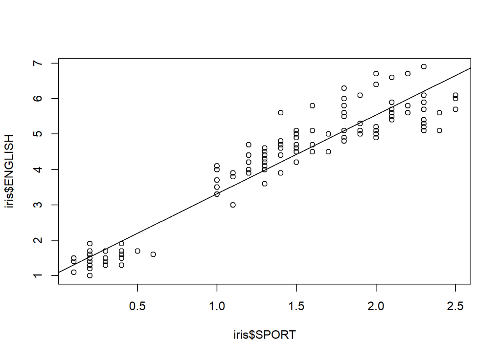

```r
plot(iris$SPORT, iris$ENGLISH)
lm(ENGLISH ~ SPORT, data = iris) |> abline()
```

#### Regression

```r
lm(ENGLISH ~ SPORT, data = iris)
```

```
Call:
lm(formula = ENGLISH ~ SPORT, data = iris)

Coefficients:
(Intercept)        SPORT
      1.084        2.230
```

```r
lm(ENGLISH ~ SPORT, data = iris) |> summary()
```

```
Call:
lm(formula = ENGLISH ~ SPORT, data = iris)

Residuals:
     Min       1Q   Median       3Q      Max
-1.33542 -0.30347 -0.02955  0.25776  1.39453

Coefficients:
            Estimate Std. Error t value Pr(>|t|)
(Intercept)  1.08356    0.07297   14.85   <2e-16 ***
SPORT        2.22994    0.05140   43.39   <2e-16 ***
---
Signif. codes:  0 '***' 0.001 '**' 0.01 '*' 0.05 '.' 0.1 ' ' 1

Residual standard error: 0.4782 on 148 degrees of freedom
Multiple R-squared:  0.9271,    Adjusted R-squared:  0.9266
F-statistic:  1882 on 1 and 148 DF,  p-value: < 2.2e-16
```

```r
library(sjPlot) # R-Zusatzpaket sjPlot
lm(ENGLISH ~ SPORT, data = iris) |> tab_model()
```

|  | ENGLISH |  |  |
| --- | --- | --- | --- |
| Predictors | Estimates | CI | p |
| (Intercept) | 1.08 | 0.94 – 1.23 | **<0.001** |
| SPORT | 2.23 | 2.13 – 2.33 | **<0.001** |
| Observations | 150 |  |  |
| R<sup>2</sup> / R<sup>2</sup> adjusted | 0.927 / 0.927 |  |  |

```r
lm(ENGLISH ~ SPORT, data = iris) |> as_flextable()
```

|  | Estimate | Standard Error | t value | Pr(>\|t\|) |  |
| --- | --- | --- | --- | --- | --- |
| (Intercept) | 1.084 | 0.073 | 14.850 | 0.0000 | *** |
| SPORT | 2.230 | 0.051 | 43.387 | 0.0000 | *** |

### Vorhersage der Deutsch-Leistung anhand der Mathematik-Leistung

**👷‍♂️ Übung**

Vorhersage der Deutsch-Leistung anhand der Mathematik-Leistung

1. Erstelle ein Streudiagramm mit Regressionsgerade (mach die Linie grün 🍀)
2. Erstelle einen Titel für das Streudiagramm (innerhalb des Befehls `plot()`)
3. Verändere die Beschriftung der X- und Y-Achsen (innerhalb des Befehls `plot()`)
4. Mach eine Regressionstabelle als HTML-Output